# Introduction to Reluctant Generalized Additive Modeling (RGAM)

## Cross-validation (CV)

We can perform $k$-fold cross-validation (CV) for RGAM with `cv.rgam()`. It does 10-fold cross-validation by default:

```r
cvfit <- cv.rgam(x, y, init_nz = 1:ncol(x), gamma = 0.6, verbose = FALSE)
```

We can change the number of folds using the `nfolds` option:

```r
cvfit <- cv.rgam(x, y, init_nz = 1:ncol(x), gamma = 0.6, nfolds = 5, verbose = FALSE)
```

If we want to specify which observation belongs to which fold, we can do that by specifying the `foldid` option, which is a vector of length $n$, with the $i$th element being the fold number for observation $i$.

```r
set.seed(3)
foldid <- sample(rep(seq(10), length = n))
cvfit <- cv.rgam(x, y, init_nz = 1:ncol(x), gamma = 0.6, foldid = foldid, verbose = FALSE)
```

A `cv.rgam()` call returns a `cv.rgam` object. We can plot this object to get the CV curve with error bars (one standard error in each direction). The left vertical dotted line represents `lambda.min`, the `lambda` value which attains minimum CV error, while the right vertical dotted line represents `lambda.1se`, the largest `lambda` value with CV error within one standard error of the minimum CV error.

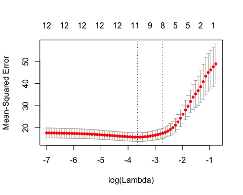

```r
plot(cvfit)
```

The numbers at the top represent the number of features in our original input matrix that are included in the model (i.e. the number of $j$ such that at least one of $\hat{\alpha}_j$ and $\hat{\beta}_j$ is non-zero).

The two special `lambda` values can be extracted directly from the `cv.rgam` object as well:

```r
cvfit$lambda.min
```

```
#> [1] 0.02595555
```

```r
cvfit$lambda.1se
```

```
#> [1] 0.06580678
```

Predictions can be made from the fitted `cv.rgam` object. By default, predictions are given for `lambda` being equal to `lambda.1se`. To get predictions are `lambda.min`, set `s = "lambda.min"`.

```r
predict(cvfit, x[1:5, ])   # s = lambda.1se
```

```
#>              1
#> [1,]  1.863440
#> [2,] -4.477733
#> [3,]  8.664422
#> [4,] -0.874814
#> [5,]  6.672235
```

```r
predict(cvfit, x[1:5, ], s = "lambda.min")
```

```
#>              1
#> [1,]  1.567028
#> [2,] -4.516911
#> [3,]  9.324387
#> [4,] -1.443938
#> [5,]  8.087449
```

## RGAM for other families

In the examples above, `y` was a quantitative variable (i.e. takes values along the real number line). As such, using the default `family = "gaussian"` for `rgam()` was appropriate. The RGAM algorithm, however, is very flexible and can be used when `y` is not a quantitative variable.

`rgam()` is currently implemented for three other family values: `"binomial"`, `"poisson"` and `"cox"`. The `rgam()` and `cv.rgam()` functions, as well as their methods, can be used as above but with the `family` option specified appropriately. In the sections below we point out some details that are particular to each family.

### Logistic regression with binary data

In this setting, the response `y` should be a numeric vector containing just 0s and 1s. When doing prediction, note that by default `predict()` gives just the value of the linear predictors, i.e.

$\log [\hat{p} / (1 - \hat{p})] = \hat{y} = \sum_{j=1}^p \hat{\alpha}_j X_j + \sum_{j = 1}^p \hat{\beta}_j \hat{f}_j(X_j),$

where $\hat{p}$ is the predicted probability. To get the predicted probability, the user has to pass `type = "response"` to the `predict()` call.

```r
# fit binary model
bin_y <- ifelse(y > 0, 1, 0)
binfit <- rgam(x, bin_y, family = "binomial", init_nz = c(), gamma = 0.9,
              verbose = FALSE)

# linear predictors for first 5 observations at 10th model
predict(binfit, x[1:5, ])[, 10]
```

```
#> [1]  0.3250267 -0.6485438  0.8554076 -0.6302209  0.7420511
```

```r
# predicted probabilities for first 5 observations at 10th model
predict(binfit, x[1:5, ], type = "response")[, 10]
```

```
#> [1] 0.5805488 0.3433178 0.7017003 0.3474605 0.6774442
```

### Poisson regression with count data

For Poisson regression, the response `y` should be a vector of count data. While `rgam()` does not expect each element to be an integer, it will throw an error if any of the elements are negative.

As with logistic regression, by default `predict()` gives just the value of the linear predictors, i.e.

$\log \hat{\mu} = \hat{y} = \sum_{j=1}^p \hat{\alpha}_j X_j + \sum_{j = 1}^p \hat{\beta}_j \hat{f}_j(X_j),$

where $\hat{\mu}$ is the predicted rate. To get the predicted rate, the user has to pass `type = "response"` to the `predict()` call.

```r
# generate data
set.seed(5)
offset <- rnorm(n)
poi_y <- rpois(n, abs(mu) * exp(offset))
poifit <- rgam(x, poi_y, family = "poisson", offset = offset, verbose = FALSE)
```

```
#> init_nz not specified: setting to default (all features)
#> using default value of gamma for RGAM: 0.6
```

Note that if `offset` is supplied to `rgam()`, then an offset vector must also be supplied to `predict()` when making predictions:

```r
# rate predictions at 20th lambda value
predict(poifit, x[1:5, ], newoffset = offset, type = "response")[,20]
```

```
#> [1] 4.904281 3.940030 5.075481 3.104760 7.244539
```

### Cox regression with survival data

For Cox regression, the response `y` must be a two-column matrix with columns named `time` and `status`. The `status` column is a binary variable, with 1 indicating death and 0 indicating right censored. We note that one way to produce such a matrix is using the `Surv()` function in the `survival` package.

As with logistic and Poisson regression, by default `predict()` gives just the value of the linear predictors. Passing `type = "response"` to the `predict()` call will return the predicted relative-risk.